# Chapitre 11 : régression logistique

# Essai

## Exercice 1

1. A
2. A
3. B
4. A
5. A
6. A
7. B
8. A
9. C
10. D
11. A, B
12. C

## Exercice 2

```r
n <- 100
set.seed(48967365)
X <- sample(c("A","B","C"),100,replace=TRUE)
Y <- rep(0,n)
set.seed(487365)
Y[X=="A"] <- rbinom(sum(X=="A"),size=1,prob=0.95)
set.seed(4878365)
Y[X=="B"] <- rbinom(sum(X=="B"),size=1,prob=0.95)
set.seed(4653965)
Y[X=="C"] <- rbinom(sum(X=="C"),size=1,prob=0.05)
Y <- factor(Y)
donnees<-data.frame(Y,X)
```

```r
model1 <- glm(Y~X,data=donnees,family=binomial)
summary(model1)
```

```
##
## Call:
## glm(formula = Y ~ X, family = binomial, data = donnees)
##
## Deviance Residuals:
##     Min       1Q   Median       3Q      Max
## -2.4267  -0.2561   0.3288   0.4512   2.6207
##
## Coefficients:
##             Estimate Std. Error z value Pr(>|z|)
## (Intercept)   2.2336     0.6075   3.677 0.000236 ***
## XB            0.6568     0.9470   0.694 0.487977
## XC           -5.6348     1.1842  -4.758 1.95e-06 ***
## ---
## Signif. codes:  0 '***' 0.001 '**' 0.01 '*' 0.05 '.' 0.1 ' ' 1
##
## (Dispersion parameter for binomial family taken to be 1)
##
##     Null deviance: 129.489  on 99  degrees of freedom
## Residual deviance:  44.218  on 97  degrees of freedom
## AIC: 50.218
##
## Number of Fisher Scoring iterations: 6
```

On obtient les résultats du **test de Wald** sur la nullité des paramètres $\beta_0,\beta_2$ et $\beta_3$.

```r
model2 <- glm(Y~C(X,base=3),data=donnees,family=binomial)
summary(model2)
```

```
##
## Call:
## glm(formula = Y ~ C(X, base = 3), family = binomial, data = donnees)
##
## Deviance Residuals:
##     Min       1Q   Median       3Q      Max
## -2.4267  -0.2561   0.3288   0.4512   2.6207
##
## Coefficients:
##                 Estimate Std. Error z value Pr(>|z|)
## (Intercept)       -3.401      1.017  -3.346  0.00082 ***
## C(X, base = 3)1    5.635      1.184   4.758 1.95e-06 ***
## C(X, base = 3)2    6.292      1.249   5.035 4.77e-07 ***
## ---
## Signif. codes:  0 '***' 0.001 '**' 0.01 '*' 0.05 '.' 0.1 ' ' 1
##
## (Dispersion parameter for binomial family taken to be 1)
##
##     Null deviance: 129.489  on 99  degrees of freedom
## Residual deviance:  44.218  on 97  degrees of freedom
## AIC: 50.218
##
## Number of Fisher Scoring iterations: 6
```

On obtient les résultats du **test de Wald** sur la nullité des paramètres $\beta_0,\beta_1$ et $\beta_2$.

4. On remarque que dans **model1** on accepte la nullité de $\beta_2$ alors qu’on la rejette dans **model2**. Ceci est logique dans la mesure où ces tests dépendent de la contrainte identifiante choisie. Dans **model1** le test de nullité de $\beta_2$ permet de vérifier si $B$ à un effet similaire à $A$ sur $Y$. Dans **model2**, on compare l’effet de $B$ à celui de $C$. On peut donc conclure $A$ et $B$ ont des effets proches sur $Y$ alors que $B$ et $C$ ont un impact différent. Ceci est logique vu la façon dont les données ont été générées.
5. Tester l’effet global de $X$ sur $Y$ revient à tester si les coefficients $\beta_1,\beta_2$ et $\beta_3$ sont égaux, ce qui, compte tenu des contraintes revient à considérer les hypothèses nulles :
- $\beta_2=\beta_3=0$ dans **model1** ;
- $\beta_1=\beta_2=0$ dans **model2**.

On peut effectuer les tests de **Wald** ou du **rapport de vraisemblance**. On obtient les résultats du **rapport de vraisemblance** avec :

```r
library(car)
Anova(model1,type=3,test.statistic="LR")
```

```
## Analysis of Deviance Table (Type III tests)
##
## Response: Y
##   LR Chisq Df Pr(>Chisq)
## X   85.271  2  < 2.2e-16 ***
## ---
## Signif. codes:  0 '***' 0.001 '**' 0.01 '*' 0.05 '.' 0.1 ' ' 1
```

```r
Anova(model2,type=3,test.statistic="LR")
```

```
## Analysis of Deviance Table (Type III tests)
##
## Response: Y
##                LR Chisq Df Pr(>Chisq)
## C(X, base = 3)   85.271  2  < 2.2e-16 ***
## ---
## Signif. codes:  0 '***' 0.001 '**' 0.01 '*' 0.05 '.' 0.1 ' ' 1
```

On remarque ici que ces deux tests sont identiques : ils ne dépendent pas de la contrainte identifiante choisie.

## Exercice 3

```r
set.seed(1234)
X <- c(runif(50,-1,0),runif(50,0,1))
set.seed(5678)
Y <- c(rep(0,50),rep(1,50))
df <- data.frame(X,Y)
```

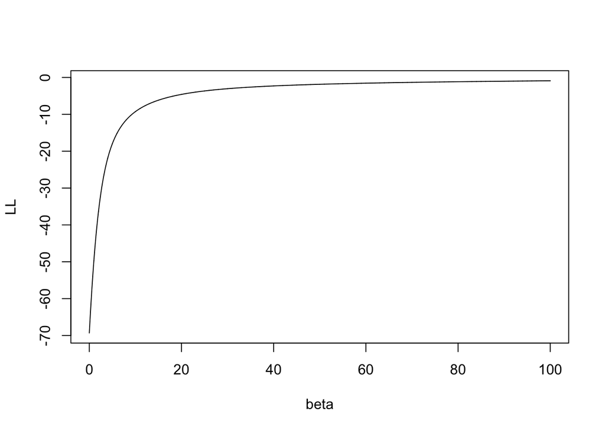

```r
beta <- seq(0,100,by=0.01)
log_vrais <- function(X,Y,beta){
  LV <- rep(0,length(beta))
  for (i in 1:length(beta)){
    Pbeta <- exp(beta[i]*X)/(1+exp(beta[i]*X))
    LV[i] <- sum(Y*X*beta[i]-log(1+exp(X*beta[i])))
#    gradln[i] <- t(Xb)%*%(Yb-Pbeta)
  }
  return(LV)
}
LL <- log_vrais(X,Y,beta)
plot(beta,LL,type="l")
```

```r
model <- glm(Y~X-1,data=df,family="binomial")
```

```
## Warning: glm.fit: algorithm did not converge
```

```
## Warning: glm.fit: fitted probabilities numerically 0 or 1 occurred
```

```r
model$coef
```

```
##        X
## 1999.371
```

On obtient un avertissement qui nous dit que l’algorithme d’optimisation n’a pas convergé.

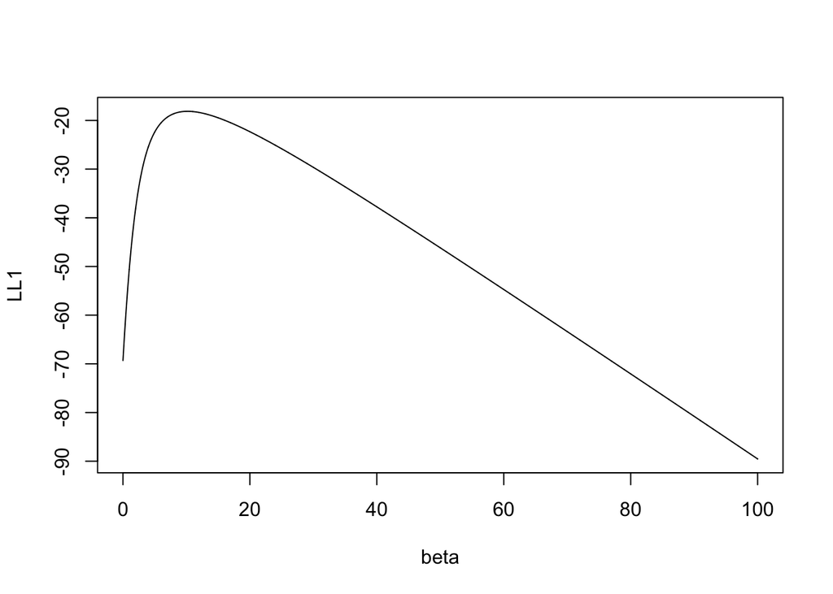

```r
Y1 <- Y;Y1[1] <- 1
LL1 <- log_vrais(X,Y1,beta)
plot(beta,LL1,type="l")
```

```r
model1 <- glm(Y1~X-1,family="binomial")
model1$coef
```

```
##        X
## 10.17868
```

## Exercice 4

## Exercice 5

On importe les données

```r
panne <- read.table("panne.txt",header=T)
head(panne)
```

```
##   etat age marque
## 1    0   4      A
## 2    0   2      C
## 3    0   3      C
## 4    0   9      B
## 5    0   7      B
## 6    0   6      A
```

1. La commande

```r
model <- glm(etat~.,data=panne,family=binomial)
model
```

```
##
## Call:  glm(formula = etat ~ ., family = binomial, data = panne)
##
## Coefficients:
## (Intercept)          age      marqueB      marqueC
##     0.47808      0.01388     -0.41941     -1.45608
##
## Degrees of Freedom: 32 Total (i.e. Null);  29 Residual
## Null Deviance:       45.72
## Residual Deviance: 43.5  AIC: 51.5
```

ajuste le modèle

$$\log\left(\frac{p_\beta(x)}{1-p_\beta(x)}\right)=\beta_0+\beta_1x_1+\beta_2\mathsf{1}_{x_2=B}+\beta_3\mathsf{1}_{x_2=C}$$

où $x_1$ et $x_2$ désigne respectivement les variables **age** et **marque**. On obtient les estimateurs avec

```r
coef(model)
```

```
## (Intercept)         age     marqueB     marqueC
##  0.47808311  0.01388395 -0.41941071 -1.45608147
```

Il s’agit des tests de Wald pour tester l’effet des variables dans le modèle. Pour l’effet de marque, on va par exemple tester
$$H_0:\beta_2=\beta_3=0\quad\text{contre}\quad H_1:\beta_2\neq 0\text{ ou }\beta_3\neq 0.$$
Sous $H_0$ la statistique de Wald suit une loi du $\chi^2$ à 4-2=2 degrés de liberté. Pour le test de la variable **age** le nombre de degrés de liberté manquant est 1. On retrouve cela dans la sortie

```r
library(car)
Anova(model,type=3,test.statistic="Wald")
```

```
## Analysis of Deviance Table (Type III tests)
##
## Response: etat
##             Df  Chisq Pr(>Chisq)
## (Intercept)  1 0.3294     0.5660
## age          1 0.0218     0.8826
## marque       2 1.9307     0.3809
```

3. Il s’agit cett fois du test du rapport de vraisemblance. Les degrés de liberté manquants sont identiques.

```r
Anova(model,type=3,test.statistic="LR")
```

```
## Analysis of Deviance Table (Type III tests)
##
## Response: etat
##        LR Chisq Df Pr(>Chisq)
## age     0.02189  1     0.8824
## marque  2.09562  2     0.3507
```

4. a). Le modèle s’écrit
   $$\log\left(\frac{p_\beta(x)}{1-p_\beta(x)}\right)=\beta_0+\beta_1\mathsf{1}_{x_2=A}+\beta_2\mathsf{1}_{x_2=B}.$$

b). Le modèle ajusté ici est
$$\log\left(\frac{p_\beta(x)}{1-p_\beta(x)}\right)=\gamma_0+\gamma_1\mathsf{1}_{x_2=B}+\gamma_2\mathsf{1}_{x_2=C}.$$

Par identification on a
$$\begin{cases}
\beta_0+\beta_1=\gamma_0 \\
\beta_0+\beta_2=\gamma_0+\gamma_1 \\
\beta_0=\gamma_0+\gamma_2 \\
\end{cases}
\Longleftrightarrow
\begin{cases}
\beta_0=\gamma_0+\gamma_2 \\
\beta_1=-\gamma_2 \\
\beta_2=\gamma_1-\gamma_2 \\
\end{cases}
\Longrightarrow
\begin{cases}
\widehat\beta_0=-0.92 \\
\widehat\beta_1=1.48 \\
\widehat\beta_2=1.05 \\
\end{cases}$$

On peut retrouver ces résultats avec

```r
glm(etat~C(marque,base=3),data=panne,family="binomial")
```

```
##
## Call:  glm(formula = etat ~ C(marque, base = 3), family = "binomial",
##     data = panne)
##
## Coefficients:
##          (Intercept)  C(marque, base = 3)1  C(marque, base = 3)2
##              -0.9163                1.4759                1.0498
##
## Degrees of Freedom: 32 Total (i.e. Null);  30 Residual
## Null Deviance:       45.72
## Residual Deviance: 43.52     AIC: 49.52
```

5. Il y a interaction si l’age agit différemment sur la panne en fonction de la marque.